```python
import pandas as pd; import numpy as np; import matplotlib.pyplot as plt;
from statsmodels.tsa.arima.model import ARIMA;
from statsmodels.tsa.stattools import adfuller
from statsmodels.tsa.stattools import kpss;
from statsmodels.graphics.tsaplots import plot_acf;
from statsmodels.graphics.tsaplots import plot_pacf;
import warnings as yapping; yapping.simplefilter('ignore')
from scipy.interpolate import CubicSpline
import scipy.stats as st
from scipy.stats import t
import os

data_dir = './data'
```

# Вариант 3

## Задание 1

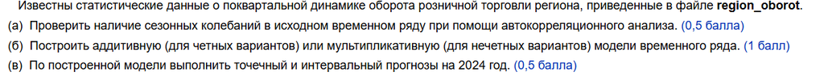

```python
data = pd.read_excel(os.path.join(data_dir, 'region_oborot.xlsx'))
data.drop([0,1],axis=0,inplace=True)
data.drop([f'Unnamed: {i}' for i in [0,3,5,6,7]],axis=1,inplace=True)
data
```

|  | Unnamed: 1 | Unnamed: 2 | Unnamed: 4 |
| --- | --- | --- | --- |
| 2 | 2020 | I | 488.4 |
| 3 | NaN | II | 741.73 |
| 4 | NaN | III | 992.31 |
| 5 | NaN | IV | 1219.9 |
| 6 | 2021 | I | 654.5 |
| 7 | NaN | II | 925.54 |
| 8 | NaN | III | 1174.69 |
| 9 | NaN | IV | 1497.32 |
| 10 | 2022 | I | 840.29 |
| 11 | NaN | II | 1157.31 |
| 12 | NaN | III | 1491.93 |
| 13 | NaN | IV | 1934.24 |
| 14 | 2023 | I | 996.82 |
| 15 | NaN | II | 1432.75 |
| 16 | NaN | III | 1905.75 |
| 17 | NaN | IV | 2528.46 |

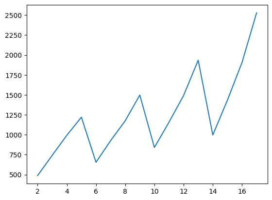

```python
data.iloc[:,2].plot()
```

На графике видно сезонность

```python
vals = data.iloc[:,2].values.reshape(4,4)
origin_data = pd.DataFrame(vals, columns=['I','II','III','IV'], index=[2020+i for i in range(4)])
origin_data
```

|  | I | II | III | IV |
| --- | --- | --- | --- | --- |
| 2020 | 488.4 | 741.73 | 992.31 | 1219.9 |
| 2021 | 654.5 | 925.54 | 1174.69 | 1497.32 |
| 2022 | 840.29 | 1157.31 | 1491.93 | 1934.24 |
| 2023 | 996.82 | 1432.75 | 1905.75 | 2528.46 |

```python
n_new = 1
y = origin_data.values.ravel()

n_new = origin_data.shape[1] * n_new

data = pd.DataFrame(origin_data.values.ravel().reshape(-1,1),index=pd.RangeIndex(1,origin_data.values.size+1,name='t'),columns=['y_t'])

data
```

| t | y_t |
| --- | --- |
| 1 | 488.4 |
| 2 | 741.73 |
| 3 | 992.31 |
| 4 | 1219.9 |
| 5 | 654.5 |
| 6 | 925.54 |
| 7 | 1174.69 |
| 8 | 1497.32 |
| 9 | 840.29 |
| 10 | 1157.31 |
| 11 | 1491.93 |
| 12 | 1934.24 |
| 13 | 996.82 |
| 14 | 1432.75 |
| 15 | 1905.75 |
| 16 | 2528.46 |

```python
data['(y_t - _y)**2'] = (data['y_t'] - data['y_t'].mean())**2
r = dict()
for i in range(1,n_new+1):
    data[f'y_t-{i}'] =data['y_t'].shift(i)
    data[f'{i}'] = (data['y_t'] - data['y_t'].mean())*(data[f'y_t-{i}'] - data['y_t'].mean())
    r[f'{i}'] = data[f'{i}'].sum()/data['(y_t - _y)**2'].sum()
```

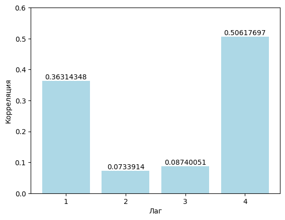

```python
def bar_plot_dict(r:dict):
        # Данные для коррелограммы
        lags = r.keys()
        correlations = r.values()

        # Создание графика
        fig, ax = plt.subplots()
        bars = ax.bar(lags, correlations, color='lightblue')

        # Добавление значений на вершины столбцов
        for bar in bars:
            yval = bar.get_height()
            ax.text(bar.get_x() + bar.get_width()/2, yval, round(yval, 8), ha='center', va='bottom')

        # Настройка осей и заголовков
        ax.set_xlabel('Лаг')
        ax.set_ylabel('Корреляция')
        ax.set_ylim(0, 0.6)

        # Отображение графика
        plt.show()

bar_plot_dict(r)
```

Из графика коррелограммы и значений коэффициентов автокорреляции видно, что наиболее тесная связь наблюдается при временном лаге 4 при умеренном коэффициенте автокорреляции 1-го порядка. Из этого следует, что во временном ряду наряду с тенденцией T присутствуют сезонные колебания S с периодичностью в 4 квартала, то есть характер динамики ежегодно повторяется. Данные предположения также подтверждаются графиком динамики наблюдаемых значений исследуемого показателя

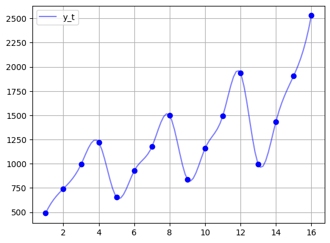

```python
def smooth_plot(datas = [], indices = [], xfroms = [], markers = [],last = True,dropna = True):

        if xfroms == []:
            xfroms = [1]*len(indices)

        lines = []

        for i in range(len(indices)):
            # Данные
            if dropna:
                y = datas[i][indices[i]].dropna().values
            else:
                y = datas[i][indices[i]].values
            x = np.arange(xfroms[i], y.size+xfroms[i], dtype = float)
            # Создание сглаживающей функции
            cs = CubicSpline(x, y)

            # Генерация новых точек для плавного графика
            x_smooth = np.linspace(x.min(), x.max(), 100)
            y_smooth = cs(x_smooth)

            if len(markers):
                plt.plot(x, y, markers[i]+'o')  # Оригинальные точки
                lines.append(plt.plot(x_smooth, y_smooth, markers[i]+'-', alpha = 0.5, label = indices[i]))  # Сглаженный график


        if last:
            plt.legend()
            plt.grid()
            plt.show()

smooth_plot([data],['y_t'],[1],['b'])
```

Из графика поквартальной динамики видно, что амплитуда колебаний постепенно увеличивается, следовательно, для моделирования такого временного ряда, целесообразнее использовать мультипликативную модель.

Произведем выравнивание исходного временного ряда с помощью скользящей средней

```python
data2 = pd.DataFrame(y.reshape(-1,1), columns=['y_t'])

k4 =[]
yc_t = []
for i in range(y.size - (n_new-1)):
    k4.append(sum([y[i+j] for j in range(n_new)]))
    yc_t.append(sum([y[i+j] for j in range(n_new)])/n_new)



data2['4k'] = [pd.NA]*(n_new//2) + k4 + [pd.NA]*(n_new - n_new//2 - 1)
data2['yc_t'] = [pd.NA]*(n_new//2) + yc_t + [pd.NA]*(n_new - n_new//2 - 1)
data2['_ycc_t'] = [pd.NA]*(n_new//2) + [(data2['yc_t'][i]+data2['yc_t'][i+1])/2 for i in range(n_new//2,y.size-n_new//2 - n_new%2)] + [pd.NA]*(n_new - n_new//2)
data2['mark'] = (data2['y_t']/data2['_ycc_t'])


data2
```

|  | y_t | 4k | yc_t | _ycc_t | mark |
| --- | --- | --- | --- | --- | --- |
| 0 | 488.4 | <NA> | <NA> | <NA> | <NA> |
| 1 | 741.73 | <NA> | <NA> | <NA> | <NA> |
| 2 | 992.31 | 3442.34 | 860.585 | 881.3475 | 1.125901 |
| 3 | 1219.9 | 3608.44 | 902.11 | 925.08625 | 1.318688 |
| 4 | 654.5 | 3792.25 | 948.0625 | 970.86 | 0.674145 |
| 5 | 925.54 | 3974.63 | 993.6575 | 1028.335 | 0.900037 |
| 6 | 1174.69 | 4252.05 | 1063.0125 | 1086.23625 | 1.081431 |
| 7 | 1497.32 | 4437.84 | 1109.46 | 1138.43125 | 1.315249 |
| 8 | 840.29 | 4669.61 | 1167.4025 | 1207.0575 | 0.696147 |
| 9 | 1157.31 | 4986.85 | 1246.7125 | 1301.3275 | 0.88933 |
| 10 | 1491.93 | 5423.77 | 1355.9425 | 1375.50875 | 1.084639 |
| 11 | 1934.24 | 5580.3 | 1395.075 | 1429.505 | 1.353084 |
| 12 | 996.82 | 5855.74 | 1463.935 | 1515.6625 | 0.657679 |
| 13 | 1432.75 | 6269.56 | 1567.39 | 1641.6675 | 0.872741 |
| 14 | 1905.75 | 6863.78 | 1715.945 | <NA> | <NA> |
| 15 | 2528.46 | <NA> | <NA> | <NA> | <NA> |

Произведя подобные преобразования, мы сгладили имевшиеся в исходном временном ряду t y сезонные колебания, что хорошо заметно на рисунке:

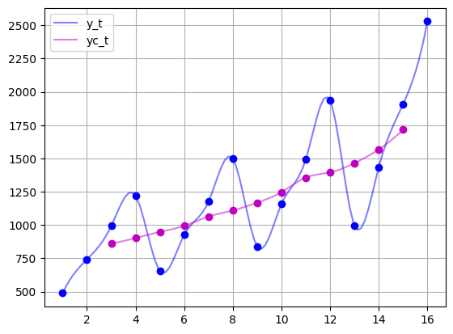

```python
smooth_plot([data,data2],['y_t','yc_t'], [1,3],['b','m'])
```

Найдем оценки сезонной компоненты как частное от деления фактических уровней ряда t y на центрированные скользящие средние cц t y. Далее рассчитаем средние значения сезонных колебаний для каждого квартала i S. Для этого перенесем имеющиеся оценки в таблицу

```python
marks = data2['mark'].fillna(0).values.reshape(*origin_data.shape).astype(float)
marks
```

```
array([[0.        , 0.        , 1.12590096, 1.31868785],
       [0.67414457, 0.90003744, 1.08143141, 1.31524851],
       [0.69614745, 0.88933032, 1.08463868, 1.35308376],
       [0.6576794 , 0.87274067, 0.        , 0.        ]])
```

```python
_S_i = marks.sum(axis=0)/np.count_nonzero(marks,0)
_S_i
```

```
array([0.67599047, 0.88736948, 1.09732369, 1.32900671])
```

Взаимопогашаемость сезонных воздействий в мультипликативной модели выражается в том, что сумма значений i S сезонной компоненты S должна быть равна числу периодов в цикле, то есть для данного примера – четырем. Суммируя i S , получаем:

```python
_S = (_S_i).sum()
_S
```

```
3.9896903422872896
```

Рассчитаем корректирующий коэффициент:

```python
k = origin_data.shape[0]/_S
k
```

```
1.0025840746594885
```

Определим скорректированные значения сезонной компоненты, умножив ее средние оценки i S на корректирующий коэффициент k:

```python
d_S_i = _S_i*k
d_S_i
```

```
array([0.67773728, 0.88966251, 1.10015925, 1.33244096])
```

Проверим выполнение свойства взаимопогашаемости сезонных колебаний в мультипликативной модели:

```python
d_S_i.sum()
```

```
4.000000000000001
```

Для выполнения последующих расчетов перенесем полученные значения S в таблицу в соответствии с каждым кварталом.

```python
data3 = pd.DataFrame(data.loc[:,'y_t'])
data3['S'] = list(d_S_i)*origin_data.shape[0]
data3
```

| t | y_t | S |
| --- | --- | --- |
| 1 | 488.4 | 0.677737 |
| 2 | 741.73 | 0.889663 |
| 3 | 992.31 | 1.100159 |
| 4 | 1219.9 | 1.332441 |
| 5 | 654.5 | 0.677737 |
| 6 | 925.54 | 0.889663 |
| 7 | 1174.69 | 1.100159 |
| 8 | 1497.32 | 1.332441 |
| 9 | 840.29 | 0.677737 |
| 10 | 1157.31 | 0.889663 |
| 11 | 1491.93 | 1.100159 |
| 12 | 1934.24 | 1.332441 |
| 13 | 996.82 | 0.677737 |
| 14 | 1432.75 | 0.889663 |
| 15 | 1905.75 | 1.100159 |
| 16 | 2528.46 | 1.332441 |

Исключим из исходного временного ряда сезонные колебания, разделив каждый уровень t y на соответствующее значение i S. В итоге получим временной ряд, содержащий только тенденцию T и случайную компоненту E.

```python
data3['TE'] = data3['y_t']/data3['S']
data3
```

| t | y_t | S | TE |
| --- | --- | --- | --- |
| 1 | 488.4 | 0.677737 | 720.633219 |
| 2 | 741.73 | 0.889663 | 833.720647 |
| 3 | 992.31 | 1.100159 | 901.969417 |
| 4 | 1219.9 | 1.332441 | 915.537752 |
| 5 | 654.5 | 0.677737 | 965.713435 |
| 6 | 925.54 | 0.889663 | 1040.327083 |
| 7 | 1174.69 | 1.100159 | 1067.745417 |
| 8 | 1497.32 | 1.332441 | 1123.7421 |
| 9 | 840.29 | 0.677737 | 1239.846207 |
| 10 | 1157.31 | 0.889663 | 1300.841602 |
| 11 | 1491.93 | 1.100159 | 1356.10367 |
| 12 | 1934.24 | 1.332441 | 1451.651563 |
| 13 | 996.82 | 0.677737 | 1470.805908 |
| 14 | 1432.75 | 0.889663 | 1610.442151 |
| 15 | 1905.75 | 1.100159 | 1732.249214 |
| 16 | 2528.46 | 1.332441 | 1897.615038 |

Решим систему уравнений для получения коэффициентов модели

```python
from sympy import symbols, Eq,solve
b0, b1 = symbols('b0 b1')

# Запись уравнений системы
eq1 = Eq(data3.index.size * b0 + pd.Series(data3.index).sum() * b1, data3['TE'].sum())
eq2 = Eq(pd.Series(data3.index).sum() * b0 + (pd.Series(data3.index)**2).sum() * b1, (data3.index*data3['TE']).sum())

# Решение системы уравнений
solution = solve((eq1, eq2), (b0, b1))

# Вывод решения
print("b0 =", solution[b0])
print("b1 =", solution[b1])
b0 = float(solution[b0])
b1 = float(solution[b1])
```

```
b0 = 627.783343770040
b1 = 70.4736097361688
```

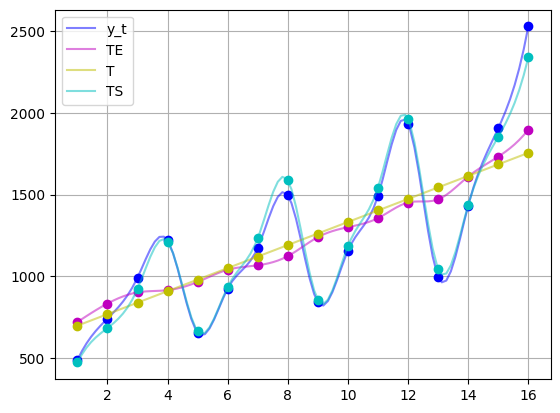

```python
data3['T'] = pd.Series(b0 + np.arange(0,data.shape[0] +1)*b1)
data3['TS'] = data3['T']*data3['S']
data['e_t'] =  data['y_t']-data3['TS']
smooth_plot([data3]*4,['y_t','TE','T','TS'],markers=['b','m','y','c'])
```

Таким образом, мультипликативную модель изучаемого временного ряда можно представить следующим образом:

```python
from IPython.display import Math

Math(f'y = ({b0} + {b1}' + r'\times t)\times \hat{S_i} \times e_t')
```

$\displaystyle y = (627.78334377004 + 70.47360973616883\times t)\times \hat{S_i} \times e_t$

Для расчета показателей качества модели значения отн t e относительной ошибки E не могут быть использованы. Поэтому для оценки качества модели необходимо рассчитать значения абсолютной ошибки по формуле Eабс=Yt - (T·S), то есть ) Значения остатков t e представлены в графе 1.

```python
data4 = pd.DataFrame(data.loc[:,'e_t'])
data4['(dyt - _y_t)**2'] = (data3['TS'] - data['y_t'].mean())**2
data4['(y_t - dyt)**2'] = (data3['TS'] - data['y_t'])**2
data4['|y_t - dyt|/y_t'] = np.abs(data3['TS'] - data['y_t'])/data['y_t'] * 100
data4
```

| t | e_t | (dyt - _y_t)**2 | (y_t - dyt)**2 | \|y_t - dyt\|/y_t |
| --- | --- | --- | --- | --- |
| 1 | 15.165229 | 6.016119e+05 | 229.984182 | 3.105084 |
| 2 | 57.819241 | 3.191804e+05 | 3343.064582 | 7.795187 |
| 3 | 69.051764 | 1.060238e+05 | 4768.146167 | 6.958689 |
| 4 | 7.808063 | 1.352718e+03 | 60.965855 | 0.640058 |
| 5 | -9.785142 | 3.417409e+05 | 95.749 | 1.495056 |
| 6 | -9.161672 | 9.870252e+04 | 83.936241 | 0.989873 |
| 7 | -58.697011 | 2.397617e+02 | 3445.339079 | 4.996809 |
| 8 | -90.379633 | 1.148047e+05 | 8168.478041 | 6.036093 |
| 9 | -15.045513 | 1.548704e+05 | 226.367462 | 1.790514 |
| 10 | -28.182585 | 4.016855e+03 | 794.258121 | 2.43518 |
| 11 | -51.585786 | 8.681540e+04 | 2661.093321 | 3.457655 |
| 12 | -29.067329 | 5.104189e+05 | 844.90963 | 1.502778 |
| 13 | -49.565884 | 4.100032e+04 | 2456.776876 | 4.972401 |
| 14 | -3.533498 | 3.512335e+04 | 12.485611 | 0.246624 |
| 15 | 52.105439 | 3.657508e+05 | 2714.976747 | 2.734117 |
| 16 | 189.544974 | 1.188195e+06 | 35927.297317 | 7.496459 |

```python
Math(r'\hat{S_i} = ' + f'{list(d_S_i)}')
```

$\displaystyle \hat{S_i} = [0.6777372831706586, 0.8896625060995372, 1.1001592524505148, 1.33244095827929]$

Предсказанные значения:

```python
def hat_y(t):
        return (b0 + b1*t)* d_S_i[t%len(d_S_i)-1]

h_y = np.vectorize(hat_y)

predicted = h_y(range(data.shape[0] +1 ,data.shape[0] +1 + n_new))
predicted
```

```
array([1237.43625539, 1687.07441144, 2163.77333647, 2714.52272197])
```

Рассчитаем стандартную ошибку регрессии:

```python
S_e = np.sqrt(data4['(y_t - dyt)**2'].sum()/(data.shape[0] - 1 - 1))
S_e
```

```
68.57416643561601
```

Cтандартные ошибки прогноза будут следующими:

```python
def s_e(t):
    return S_e * np.sqrt(1 + 1/data.shape[0] + (t - np.mean(data.index))**2/np.sum((data.index - np.mean(data.index))**2))

std = np.vectorize(s_e)


errors = std(range(data.shape[0] +1 ,data.shape[0] +1 + n_new))
errors
```

```
array([77.43113576, 79.02235277, 80.75360649, 82.61609381])
```

Нахождение критического значения t

```python
alpha = 0.95
degrees_of_freedom = data.shape[0] - 2
t_critical = t.ppf(1 - (1 - alpha) / 2, degrees_of_freedom)

lower_boarder = (h_y(range(data.shape[0] +1 ,data.shape[0] +1 + n_new)) - std(range(data.shape[0] +1 ,data.shape[0] +1 + n_new)) * t_critical)
upper_boarder = (h_y(range(data.shape[0] +1 ,data.shape[0] +1 + n_new)) + std(range(data.shape[0] +1 ,data.shape[0] +1 + n_new)) * t_critical)

print(f"Критическое значение t_{{0.95;{degrees_of_freedom}}} = {t_critical:.2f}")
```

```
Критическое значение t_{0.95;14} = 2.14
```

Границы предсказаний

```python
data5 = pd.DataFrame(np.hstack((data3.iloc[:,4].values,predicted)),columns =['predict'])



data6 = pd.DataFrame(np.vstack((lower_boarder, upper_boarder)).T, columns=['lower_boarder','upper_boarder'])
data6
```

|  | lower_boarder | upper_boarder |
| --- | --- | --- |
| 0 | 1071.362986 | 1403.509525 |
| 1 | 1517.588321 | 1856.560502 |
| 2 | 1990.574076 | 2336.972597 |
| 3 | 2537.328824 | 2891.716620 |

Итоговый график модели

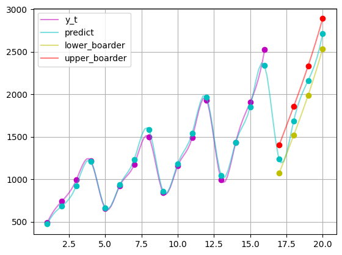

```python
smooth_plot([data3,data5,data6,data6],['y_t','predict','lower_boarder','upper_boarder'],[1,1,data.shape[0]+1,data.shape[0]+1],markers=['m','c','y','r'])
```

Коэффициент детерминации

```python
R2 = data4['(dyt - _y_t)**2'].sum()/(data4['(dyt - _y_t)**2'].sum() + data4['(y_t - dyt)**2'].sum())
R2
```

```
0.983687062386617
```

Средняя ошибка аппроксимации

```python
A_ = data4['|y_t - dyt|/y_t'].mean()
A_
```

```
3.5407860092523546
```

## Задание 2

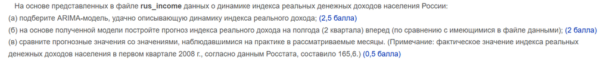

### (а) подберите ARIMA-модель, удачно описывающую динамику индекса реального дохода;

```python
data = pd.read_excel(os.path.join(data_dir, 'rus_income.xlsx'), names = ['period','I'])
data.drop(list(range(3)), axis=0,inplace = True)
periods = data['period']

data.drop('period', axis=1,inplace=True)
data.reset_index(inplace=True)

data.drop('index', axis=1,inplace=True)
data
```

|  | I |
| --- | --- |
| 0 | 100 |
| 1 | 88 |
| 2 | 97.7 |
| 3 | 102.6 |
| 4 | 106.7 |
| 5 | 96 |
| 6 | 110.4 |
| 7 | 122.5 |
| 8 | 121.4 |
| 9 | 91.1 |
| 10 | 98.4 |
| 11 | 99.4 |
| 12 | 98.4 |
| 13 | 92.5 |
| 14 | 95.2 |
| 15 | 95.3 |
| 16 | 106.8 |
| 17 | 96.3 |
| 18 | 103.8 |
| 19 | 100.8 |
| 20 | 110.7 |
| 21 | 87.7 |
| 22 | 91.1 |
| 23 | 82.9 |
| 24 | 84.5 |
| 25 | 64.8 |
| 26 | 71.4 |
| 27 | 72.2 |
| 28 | 87.8 |
| 29 | 74.8 |
| 30 | 84.3 |
| 31 | 85.9 |
| 32 | 96.3 |
| 33 | 80.6 |
| 34 | 90.5 |
| 35 | 95.5 |
| 36 | 104.8 |
| 37 | 88.5 |
| 38 | 99.1 |
| 39 | 104.1 |
| 40 | 120.9 |
| 41 | 104.6 |
| 42 | 114.3 |
| 43 | 117.6 |
| 44 | 138.7 |
| 45 | 118.3 |
| 46 | 124 |
| 47 | 128.8 |
| 48 | 153.6 |
| 49 | 125.2 |
| 50 | 142.8 |
| 51 | 147 |
| 52 | 175.4 |
| 53 | 137.7 |
| 54 | 165 |
| 55 | 168.3 |
| 56 | 199.2 |
| 57 | 154 |
| 58 | 181.4 |
| 59 | 189.2 |

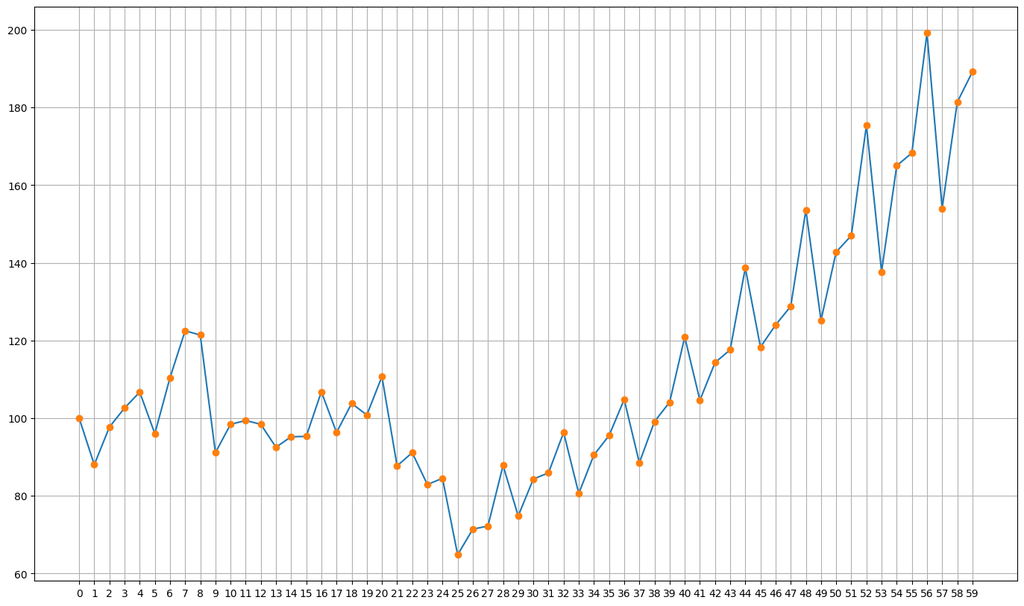

```python
plt.figure(dpi = 100, figsize=(17, 10))
plt.plot(data)
plt.plot(data,'o')
plt.xticks(data.index)
plt.grid()
plt.show()
```

Наблюдаем неструктуризированные данные до 25го измерения. Будем строить модель с 25го измерения

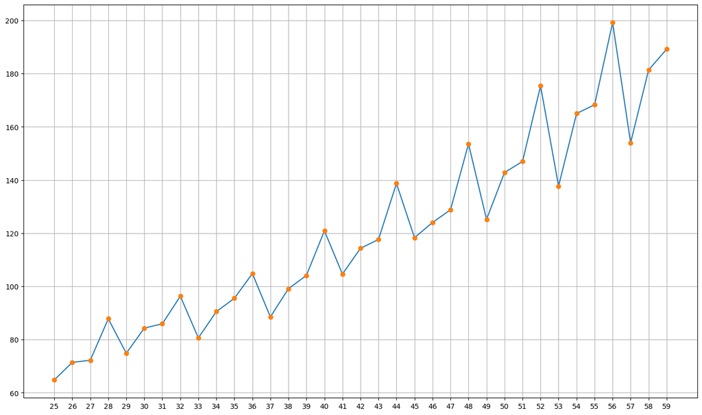

```python
data.drop(list(range(25)), axis=0,inplace = True)

plt.figure(dpi = 100, figsize=(17, 10))
plt.plot(data)
plt.plot(data,'o')
plt.xticks(data.index)
plt.grid()
plt.show()
```

```python
datacopy = data.copy()

d = 0

result = adfuller(datacopy.diff().dropna())
print(f'p-value = {result[1]}\np-value < 0.05: {result[1] < 0.05}\n')

if result[1] < 0.05:
    d = 1
else:
    d = 1
    while not result[1] < 0.05:
        datacopy = datacopy.diff()
        result = adfuller(datacopy.diff().dropna())
        print(f'p-value = {result[1]}\np-value < 0.05: {result[1] < 0.05}\n')
        d+=1

print(f'd = {d}')
```

```
p-value = 0.4011960695579423
p-value < 0.05: False

p-value = 0.01486007794604307
p-value < 0.05: True

d = 2
```

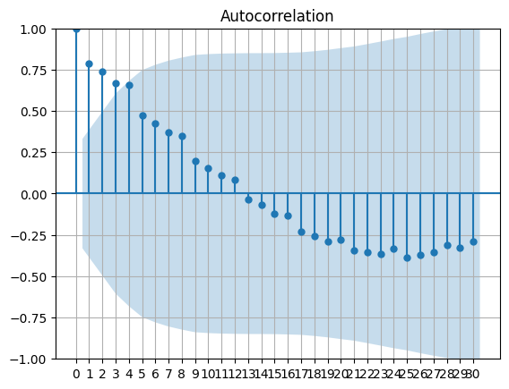

```python
plt.figure(dpi = 100, figsize=(17, 10))
plot_acf(data, lags=30, alpha=0.05)
plt.xticks(range(31))
plt.grid()
plt.show()
```

Наблюдаем значимую автокорреляцию на 3 лаге, после которой на других лагах автокорреляция незначимая и падает к 0

```python
q = 3
```

Определим p

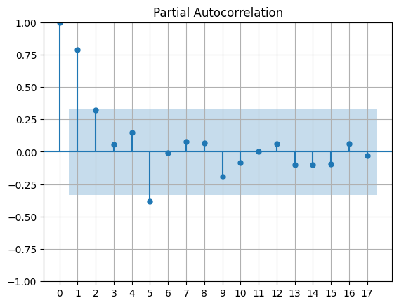

```python
plot_pacf(data, lags=17, alpha=0.05)  # PACF (для выбора p)
plt.xticks(range(18))
plt.grid()
plt.show()
```

Значение p — это номер первого значимого лага, после которого PACF становится очень близка к нулю

```python
p = 5
```

```python
data['I'] = data['I'].astype(np.float64)
```

```python
order = (p,d,q)

arima = ARIMA(data['I'],order=order).fit()
arima.summary()
```

SARIMAX Results

| Dep. Variable: | I | No. Observations: | 35 |
| --- | --- | --- | --- |
| Model: | ARIMA(5, 2, 3) | Log Likelihood | -96.990 |
| Date: | Пт, 28 мар 2025 | AIC | 211.980 |
| Time: | 09:55:47 | BIC | 225.449 |
| Sample: | 0 | HQIC | 216.512 |
|  | - 35 |  |  |
| Covariance Type: | opg |  |  |

|  | coef | std err | z | P>\|z\| | [0.025 | 0.975] |
| --- | --- | --- | --- | --- | --- | --- |
| ar.L1 | 0.5404 | 0.352 | 1.534 | 0.125 | -0.150 | 1.231 |
| ar.L2 | -0.2778 | 0.204 | -1.364 | 0.173 | -0.677 | 0.122 |
| ar.L3 | -0.2848 | 0.207 | -1.376 | 0.169 | -0.690 | 0.121 |
| ar.L4 | 0.6518 | 0.180 | 3.624 | 0.000 | 0.299 | 1.004 |
| ar.L5 | -0.8613 | 0.362 | -2.379 | 0.017 | -1.571 | -0.152 |
| ma.L1 | -2.2672 | 0.558 | -4.060 | 0.000 | -3.362 | -1.173 |
| ma.L2 | 2.0856 | 1.029 | 2.028 | 0.043 | 0.070 | 4.101 |
| ma.L3 | -0.7225 | 0.446 | -1.621 | 0.105 | -1.596 | 0.151 |
| sigma2 | 13.5448 | 7.129 | 1.900 | 0.057 | -0.428 | 27.517 |

| Ljung-Box (L1) (Q): | 0.27 | Jarque-Bera (JB): | 0.85 |
| --- | --- | --- | --- |
| Prob(Q): | 0.60 | Prob(JB): | 0.65 |
| Heteroskedasticity (H): | 3.74 | Skew: | 0.05 |
| Prob(H) (two-sided): | 0.04 | Kurtosis: | 2.22 |

Warnings:  
[1] Covariance matrix calculated using the outer product of gradients (complex-step).

### (б) на основе полученной модели постройте прогноз индекса реального дохода на полгода (2 квартала) вперед (по сравнению с имеющимися в файле данными);

прогноз на два шага

```python
forecast_steps = 2
forecast = arima.forecast(steps=forecast_steps)
delta = 25
```

Визуализация

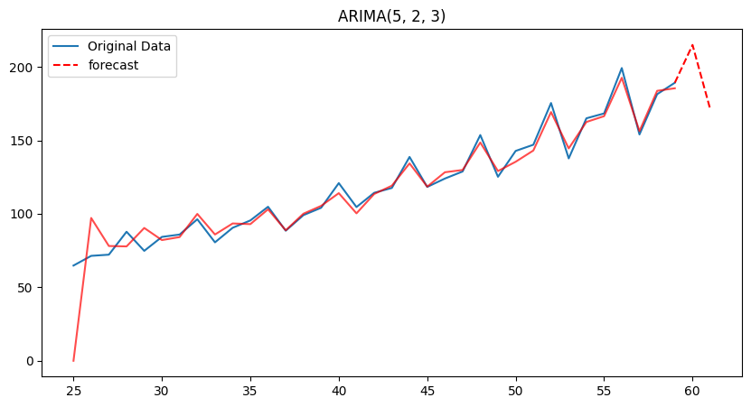

```python
plt.figure(figsize=(10,5))
plt.plot(data, label="Original Data")
plt.plot(data.index, arima.predict(), color='red', alpha=0.7)
plt.plot(range(len(data) - 1 + delta, len(data) + forecast_steps+ delta), np.hstack([data.iloc[-1], forecast]), label="forecast", linestyle="--", color="red")
plt.legend()
plt.title(f"ARIMA{order}")
plt.show()
```

```python
forecast
```

```
60    214.929454
61    171.186313
Name: predicted_mean, dtype: float64
```

### (в) сравните прогнозные значения со значениями, наблюдавшимися на практике в рассматриваемые месяцы. (Примечание: фактическое значение индекса реальных денежных доходов населения в первом квартале 2008 г., согласно данным Росстата, составило 165,6.)

```python
(forecast.iloc[-1] - 165.6)/165.6
```

```
0.03373377392870983
```

Отличия прогноза и фактических данных незначительны - всего 3 процента